# Data Analysis Project: Knee Replacement Surgery Outcomes

Analysis Project

Gitika Jain (gitikaj2)

Heather Sewak (hsewak2)

Ionel Miu (imiu2)

Jared Michael Colbert (jaredc2)

December 14, 2016

# Knee Replacement Surgery Outcome

## Introduction

This research aims to determine if the postoperative function of a total knee replacement recipient can be modeled based on anthropomorphic data and details of the surgical procedure. We decided to carry out testing on models with two postoperative scoring systems as the response variable. The first score is the “Surgeon’s Score” which measures more objective postoperative metrics about the condition of the replaced knee following surgery. These metrics include: how straight or how flexed the patient can make thier knee, how well aligned the knee appears when inspecting from a frontal perspective and how much laxity or separation can be achieved by placing the lower leg under tension. Finally, the patient is asked about the overall pain they experience with the knee. The resulting score is a value between 0-100 with 80-100 being an excellent result.

The second score we model is the “Patient’s Score” which is generated by three questions: how far are they able to walk, how well can they navigate stairs and do they require any walking aids (crutches, cane, etc).

We hope to create a model that can predict each of the scores based on a variety of categorical and numeric predictors.

## Background information

This data has been collected from a Southern California Hospital in collaboration with the Shiley Center for Orthopedic Research. The data is used for both clinical research and postoperative monitoring of implant survivorship. All patient specific information has been removed from the data so it adheres to the Health Insurance Portability and Accountability Act (HIPAA).

## Statement

We hope to determine the impact a particular surgeon or the type of implants used has on the patient’s outcome after surgery. We are also interested in exploring the potential relationship between anthropomorphic factors and the patient’s postoperative satisfaction. Finally, we would like to understand if the considerable expense of computer navigation in knee replacement leads to better postoperative scores. Nevertheless, we keep our option opened to investigate other aspects that were not ‘visibile’ or never thought about it but might reveal themselfs as we move on with the project.

Here we may consider *KneeScore_Surgeon* or *KneeScore_Patient* as response and *Age, Gendar, Weight, Height, BMI, Race, Side, Manufacturer* as predictors. *Gendar, Race, Side and Manufacturer* are some of the categorical predictors and *Age, Height, Weight and BMI* are numerical predictors.

```r
knee = read.csv('knees.csv')
knee$Surgeon = as.factor(knee$Surgeon)
knee$Year = as.factor(knee$Year)
```

### Functions for model evaluation

```r
plots = function(model) {
  par(mfcol=c(2,2))
  qqnorm(resid(model), col = red, pch = 16)
  qqline(resid(model), col = lightblue, lwd = 2)
  plot(fitted(model), resid(model), xlab = 'Fitted Values', ylab = 'Residuals', main = 'Fitted vs. Residuals Plot', col = purple, pch = 16)
  abline(h = 0, col = green, lwd = 2)
  hist(resid(model), col = blue, main = 'Histogram of Residuals', xlab = 'Residuals')
}

evaluate = function(model){
  # Run each of the tests
  lambda = 1.000001 # this is a hack so the function will return a CrossValidation score - HatValues of 1.0 are causing a division by zero error.
  shapiroTest = shapiro.test(resid(model))
  bpTest = bptest(model)
  rSquared = summary(model)$r.squared
  adjRSquared = summary(model)$adj.r.squared
  loocv = sqrt(mean((resid(model) / (lambda - hatvalues(model))) ^ 2))
  large_hat = sum(hatvalues(model) > 2 * mean(hatvalues(model)))
  large_resid = sum(rstandard(model)[abs(rstandard(model)) > 2]) / (length(rstandard(model) + lambda))


  # Collect tests in dataframe
  values = data.frame(Result = c(prettyNum(shapiroTest$p.value), prettyNum(bpTest$p.value), prettyNum(rSquared), prettyNum(adjRSquared),prettyNum(loocv),               prettyNum(large_hat)))
  rowNames = data.frame(Test = c('Shapiro Wilk pvalue', 'Breusch-Pagan pvalue', 'R Squared', 'Adj R Squared', 'Cross Validation', 'Large Hat Values'))

  summary_output = cbind(rowNames, values)
  show(summary_output)
  plots(model)
}

removeInfluential = function(model, data){
  large_lev_index = which(hatvalues(model) > 2 * mean(hatvalues(model)))
  cooks = which(cooks.distance(model) > 4 / length(cooks.distance(model)))
  rStandard = abs(rstandard(model))
  rStandardIndex = which(rStandard > 2)
  index_ = intersect(intersect(large_lev_index, cooks), rStandardIndex)
  newData = data[-index_ , ]
  return(newData)
}

IdentifyInfluential = function(model, data){
  large_lev_index = which(hatvalues(model) > 2 * mean(hatvalues(model)))
  cooks = which(cooks.distance(model) > 4 / length(cooks.distance(model)))
  rStandard = abs(rstandard(model))
  rStandardIndex = which(rStandard > 2)
  index_ = intersect(intersect(large_lev_index, cooks), rStandardIndex)
  return(index_)
}
removeLargeHatValues = function(model, data){
  largeHat = which(hatvalues(model) > 2 * mean(hatvalues(model)))
  newData = data[-largeHat, ]
  return(newData)
}

prediction_accuracy = function(model, data, margin) {
  upper = data + margin
  lower = data - margin
  prediction = predict(model, newdata = data)
  return(sum(prediction < upper & lower < prediction)) / length(prediction)
}
```

### Knee Score Surgeon

Begin by fitting a full additive model as a baseline and evaluating.

```r
full_additive_model = lm(KneeScore_Surgeon ~ ., data = knee)
evaluate(full_additive_model)
```

```
##                   Test       Result
## 1  Shapiro Wilk pvalue 2.080142e-08
## 2 Breusch-Pagan pvalue    0.9192514
## 3            R Squared    0.2718411
## 4        Adj R Squared    0.2130606
## 5     Cross Validation      14.4126
## 6     Large Hat Values          177
```

The baseline model has many large leverage values, which, upon inspection may be coming from several of the implant fields. Perhaps removing the suspect implant predictors will help improve the model.

```r
model_eight = lm(KneeScore_Surgeon ~ . - Diagnosis - Race - TibialInsertType - FemoralComponentModel - PatellaModel - TibialTrayModel - TibialTraySize - FemoralComponentType, data = knee)
evaluate(model_eight)
```

```
##                   Test       Result
## 1  Shapiro Wilk pvalue 3.989833e-07
## 2 Breusch-Pagan pvalue    0.1270351
## 3            R Squared    0.2374036
## 4        Adj R Squared    0.2084443
## 5     Cross Validation     14.34844
## 6     Large Hat Values          126
```

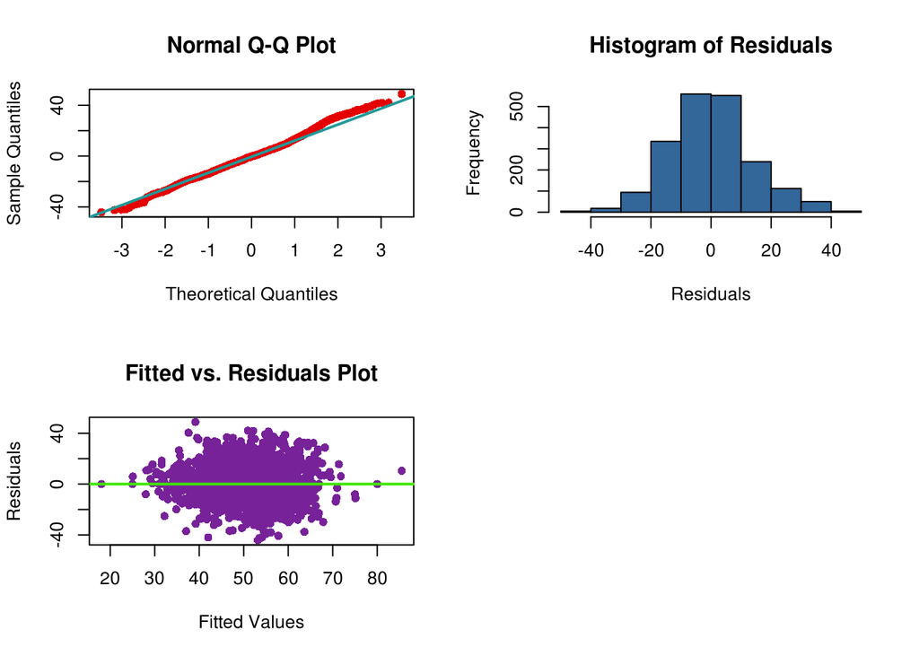

```r
anova(model_eight, full_additive_model)
```

```
## Analysis of Variance Table
##
## Model 1: KneeScore_Surgeon ~ (Surgeon + Year + Age + Gender + Weight +
##     Height + BMI + Diagnosis + Race + Side + KneeScore_Patient +
##     GPS + Manufacturer + FemoralComponentModel + FemoralComponentSize +
##     FemoralComponentType + TibialTrayModel + TibialTraySize +
##     TibialInsertModel + TibialInsertWidth + TibialInsertType +
##     PatellaModel + PatellaDiameter) - Diagnosis - Race - TibialInsertType -
##     FemoralComponentModel - PatellaModel - TibialTrayModel -
##     TibialTraySize - FemoralComponentType
## Model 2: KneeScore_Surgeon ~ Surgeon + Year + Age + Gender + Weight +
##     Height + BMI + Diagnosis + Race + Side + KneeScore_Patient +
##     GPS + Manufacturer + FemoralComponentModel + FemoralComponentSize +
##     FemoralComponentType + TibialTrayModel + TibialTraySize +
##     TibialInsertModel + TibialInsertWidth + TibialInsertType +
##     PatellaModel + PatellaDiameter
##   Res.Df    RSS Df Sum of Sq      F Pr(>F)
## 1   1896 379610
## 2   1821 362468 75     17142 1.1483 0.1845
```

Utilize a Bayesian Information Criterion approach and evaluate the selected model.

```r
n = length(resid(full_additive_model))
model_back_bic = step(full_additive_model, direction = "backward", k = log(n), trace = 0)
evaluate(model_back_bic)
```

```
##                   Test       Result
## 1  Shapiro Wilk pvalue 1.169168e-05
## 2 Breusch-Pagan pvalue 0.0001309477
## 3            R Squared    0.1869122
## 4        Adj R Squared    0.1852562
## 5     Cross Validation     14.37628
## 6     Large Hat Values           87
```

```r
anova(model_back_bic, full_additive_model)
```

```
## Analysis of Variance Table
##
## Model 1: KneeScore_Surgeon ~ Age + Side + KneeScore_Patient
## Model 2: KneeScore_Surgeon ~ Surgeon + Year + Age + Gender + Weight +
##     Height + BMI + Diagnosis + Race + Side + KneeScore_Patient +
##     GPS + Manufacturer + FemoralComponentModel + FemoralComponentSize +
##     FemoralComponentType + TibialTrayModel + TibialTraySize +
##     TibialInsertModel + TibialInsertWidth + TibialInsertType +
##     PatellaModel + PatellaDiameter
##   Res.Df    RSS  Df Sum of Sq      F   Pr(>F)
## 1   1964 404744
## 2   1821 362468 143     42276 1.4853 0.000288 ***
## ---
## Signif. codes:  0 '***' 0.001 '**' 0.01 '*' 0.05 '.' 0.1 ' ' 1
```

The resulting BIC model scores marginally better in Cross Validation though the anova results clearly prefer the full additive model.

Next, we will evaluate the RMSE of the best performing models thus far.

```r
options(warn=-1)
sample_idx = sample(1:nrow(knee), 1500)
train_data = knee[sample_idx, ]
test_data = knee[-sample_idx, ]

rmse  = function(actual, predicted) {  sqrt(mean((actual - predicted) ^ 2))}

full_test = rmse(test_data$KneeScore_Surgeon, predict(full_additive_model, test_data))
full_train = rmse(train_data$KneeScore_Surgeon, predict(full_additive_model, train_data))

test_mod_8 = rmse(test_data$KneeScore_Surgeon, predict(model_eight, test_data))
train_mod_8 = rmse(train_data$KneeScore_Surgeon, predict(model_eight, train_data))

bic_test = rmse(test_data$KneeScore_Surgeon, predict(model_back_bic, test_data))
bic_train = rmse(train_data$KneeScore_Surgeon, predict(model_back_bic, train_data))
```

[output not shown]

** how are these evalueated again?**

Perhaps removing some influential data points will assist in creating a better model. Next we remove influential points that satisfy the criteria for `Large Leverage`, `Large Cook's Distance` and `Large RStandard` values.

```r
new_dataframe = removeInfluential(model_eight, knee)
model_nine = lm(KneeScore_Surgeon ~ . - Diagnosis - Race - TibialInsertType - FemoralComponentModel - PatellaModel - TibialTrayModel - TibialTraySize - FemoralComponentType, data = new_dataframe)
evaluate(model_nine)
```

```
##                   Test       Result
## 1  Shapiro Wilk pvalue 6.718107e-07
## 2 Breusch-Pagan pvalue    0.2390135
## 3            R Squared     0.241005
## 4        Adj R Squared    0.2124774
## 5     Cross Validation     14.17558
## 6     Large Hat Values          119
```

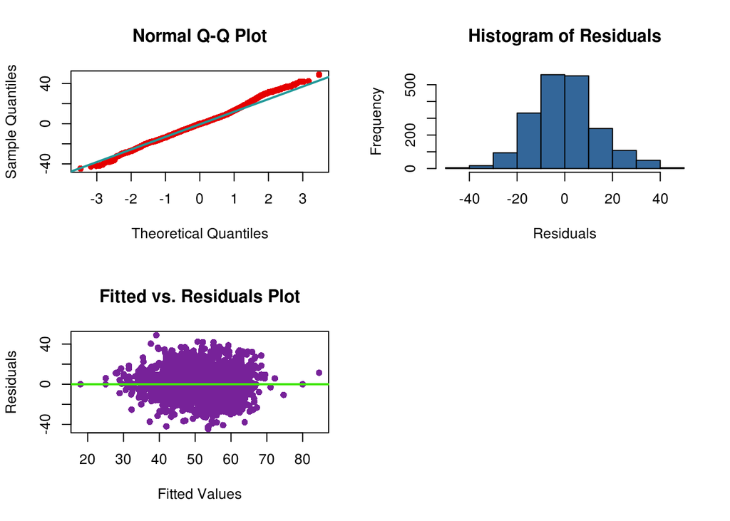

This does seem to be of moderate benefit in relation to Adjusted $R^2$ and Cross Validation.

We will evaluate the same model one again after removing the identified large hat values.

```r
remove_hat_dataframe = removeLargeHatValues(model_nine, new_dataframe)
model_ten = lm(KneeScore_Surgeon ~ . - Diagnosis - Race - TibialInsertType - FemoralComponentModel - PatellaModel - TibialTrayModel - TibialTraySize - FemoralComponentType, data = remove_hat_dataframe)
evaluate(model_ten)
```

```
##                   Test       Result
## 1  Shapiro Wilk pvalue 3.604033e-06
## 2 Breusch-Pagan pvalue   0.08198251
## 3            R Squared    0.2187277
## 4        Adj R Squared    0.2013757
## 5     Cross Validation     14.32124
## 6     Large Hat Values           93
```

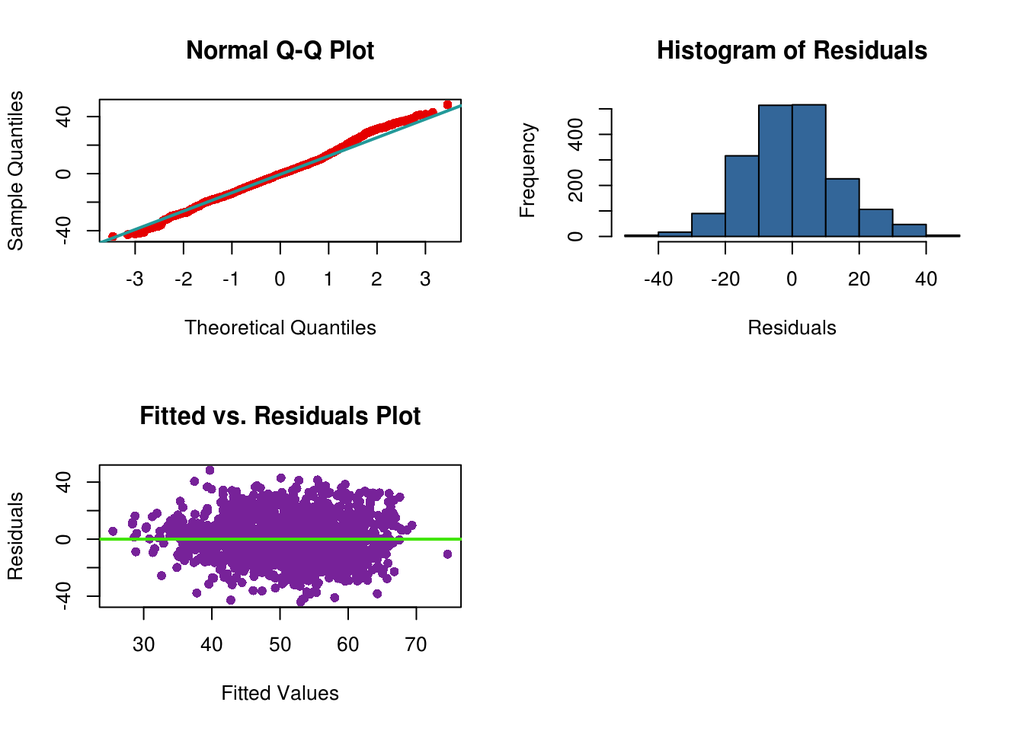

```r
n = length(resid(model_ten))
model_10_bic = step(model_ten, direction = "backward", k = log(n), trace = 0)
evaluate(model_10_bic)
```

```
##                   Test       Result
## 1  Shapiro Wilk pvalue 0.0001065612
## 2 Breusch-Pagan pvalue 8.666681e-05
## 3            R Squared    0.1862472
## 4        Adj R Squared    0.1844753
## 5     Cross Validation     14.33378
## 6     Large Hat Values           79
```

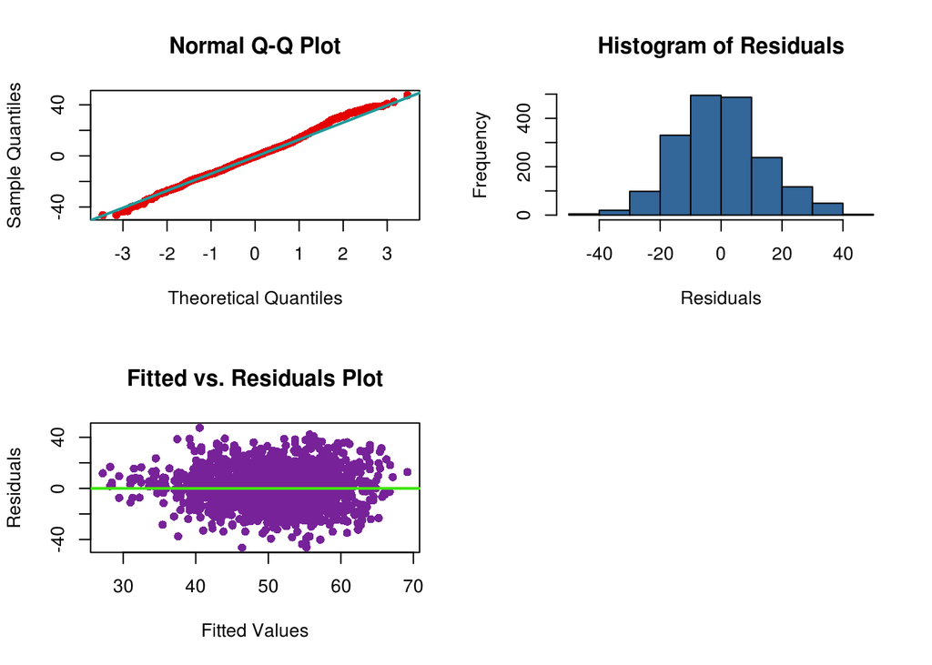

Despite the reduction in leveraged values the selected model is no better than preceeding models.

```r
sample_idx_two = sample(1:nrow(remove_hat_dataframe), 1300)
train_data_two = remove_hat_dataframe[sample_idx_two, ]
test_data_two = remove_hat_dataframe[-sample_idx_two, ]

test_mod_10 = rmse(test_data_two$KneeScore_Surgeon, predict(model_ten, train_data_two))
train_mod_10 = rmse(train_data_two$KneeScore_Surgeon, predict(model_ten, train_data_two))

test_10_bic = rmse(test_data_two$KneeScore_Surgeon, predict(model_10_bic, train_data_two))
train_10_bic = rmse(train_data_two$KneeScore_Surgeon, predict(model_10_bic, train_data_two))
```

| Model | Train RMSE | Test RMSE |
| --- | --- | --- |
| `Model 10` | 14.1157682 | 17.6808706 |
| `Model 10 BIC` | 14.4091976 | 17.3249179 |